# Reproducible Research: Peer Assessment 1

## Loading and preprocessing the data

```r
activity_df <- read.csv("activity.csv")
activity_df$date <- as.Date(activity_df$date, format = "%Y-%m-%d")
activity_df$weekday <- weekdays(activity_df$date, abbreviate = FALSE)
head(activity_df)
```

```
##   steps       date interval weekday
## 1    NA 2012-10-01        0   lundi
## 2    NA 2012-10-01        5   lundi
## 3    NA 2012-10-01       10   lundi
## 4    NA 2012-10-01       15   lundi
## 5    NA 2012-10-01       20   lundi
## 6    NA 2012-10-01       25   lundi
```

## What is mean total number of steps taken per day?

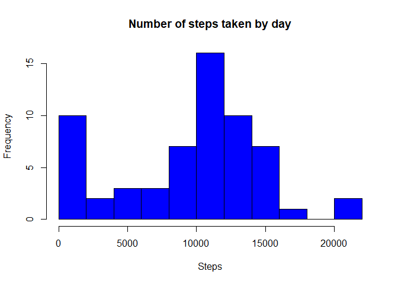

```r
stepsByDayTable <- aggregate(activity_df$steps, by= list(activity_df$date), FUN="sum", na.rm = TRUE)
names(stepsByDayTable) <- c("date", "steps")
hist(stepsByDayTable$steps, breaks = 10,
     col = "blue", border = "black",
     main = "Number of steps taken by day", xlab = "Steps")
```

Here we calculate the mean and median of the total number of steps taken by day :

```r
meanStepsByDay <- mean(stepsByDayTable$steps)
medianStepsByDay <- median(stepsByDayTable$steps)
```

The mean total number of steps taken per day is 9354.2295082 and the median total number of steps taken per day is 10395

## What is the average daily activity pattern?

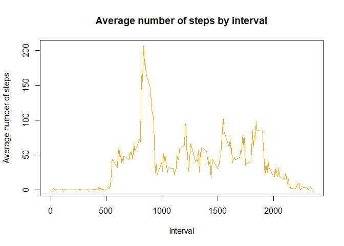

```r
averageStepsByIntervalTable <- aggregate(activity_df$steps, by=list(activity_df$interval), FUN=mean, na.rm=TRUE)
names(averageStepsByIntervalTable) <- c("interval", "meanSteps")
plot(averageStepsByIntervalTable$interval,
     averageStepsByIntervalTable$meanSteps,
     type = "l", col="orange",
     xlab="Interval", ylab="Average number of steps", main="Average number of steps by interval")
```

To find the interval that contains the max number of steps we use the which.max command

```r
averageStepsByIntervalTable[which.max(averageStepsByIntervalTable$mean), ]$interval
```

```
## [1] 835
```

## Imputing missing values

Here is the number of rows containing NA

```r
sum(is.na(activity_df$steps))
```

```
## [1] 2304
```

We fill the missing values by averaging by interval

```r
stepsMissingValues <- averageStepsByIntervalTable$mean[match(activity_df$interval, averageStepsByIntervalTable$interval)]
```

We create anew dataset with the NA values filled.

```r
activityFilled_df <- activity_df
activityFilled_df$steps <- ifelse(is.na(activity_df$steps), yes = stepsMissingValues, no = activity_df$steps)
```

We can see that there is NA values anymore :

```r
sum(is.na(activityFilled_df$steps))
```

```
## [1] 0
```

We now plot again what we did at he beginning to see if there is a difference :

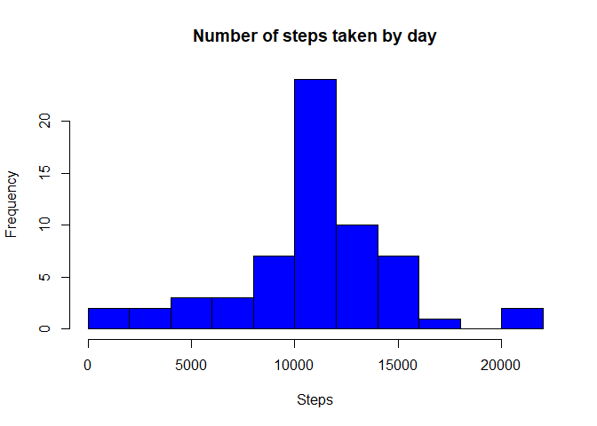

```r
stepsByDayFilledTable <- aggregate(activityFilled_df$steps,
                                   by= list(activityFilled_df$date), FUN="sum", na.rm = TRUE)
names(stepsByDayFilledTable) <- c("date", "steps")
hist(stepsByDayFilledTable$steps, breaks = 10,
     col = "blue", border = "black",
     main = "Number of steps taken by day", xlab = "Steps")
```

```r
meanStepsByDayFilled <- mean(stepsByDayFilledTable$steps)
medianStepsByDayFilled <- median(stepsByDayFilledTable$steps)
```

We notice as a difference that the spike a the 0 steps seems to have be redestributed changing a bit the repartition.

## Are there differences in activity patterns between weekdays and weekends?

```r
activity_df$dayType <- ifelse(activity_df$weekday %in% c("samedi", "dimanche"),
                              yes = "weekend", no = "weekday")
activity_df$dayType <- as.factor(activity_df$dayType)
```

And here is the plot :

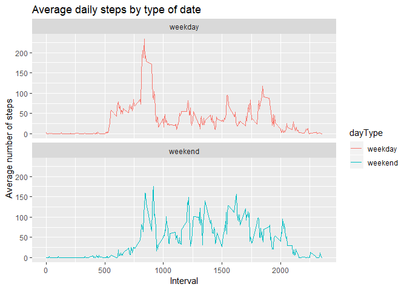

```r
library(ggplot2)
activityByDayType <- aggregate(steps~interval + dayType, activity_df, mean, na.rm = TRUE)
plot<- ggplot(activityByDayType, aes(x = interval , y = steps, color = dayType)) +
       geom_line() +
       labs(title = "Average daily steps by type of date", x = "Interval", y = "Average number of steps") +
       facet_wrap(~dayType, ncol = 1, nrow=2)
print(plot)
```